# IODS course project

Johanna Koskivuori

# Introduction to Open Data Science - Course Project

# About the project

```r
# This is a so-called "R chunk" where you can write R code.

date()
```

```
## [1] "Wed Dec 02 15:17:07 2020"
```

I am a PhD student in the School of Pharmacy, UEF. I am doing metabolomics studies in my PhD thesis and I have a huge amount of data to be analyzed. I chose this course to get some new tools for analyzing and visualizing my data. I have used R in a couple of basic statistics courses but I wish to learn some new tricks in this course.

Here is the to link to my GitHub repository: https://github.com/johannakoskivuori/IODS-project

# 2. Regression and model validation

This week I performed regression analysis and method validation for the data learning2014 that I created in the data wrangling exercise. Below you can find the analysis that was performed, more information about the data that was analyzed and of course the results I got.

```r
date()
```

```
## [1] "Wed Dec 02 15:17:07 2020"
```

```r
students2014 <- read.table("learning2014.txt", sep = ",", header = TRUE)
students2014$gender <- factor(students2014$gender) # Making gender a factor
```

```r
str(students2014)
```

```
## 'data.frame':    166 obs. of  7 variables:
##  $ gender  : Factor w/ 2 levels "F","M": 1 2 1 2 2 1 2 1 2 1 ...
##  $ age     : int  53 55 49 53 49 38 50 37 37 42 ...
##  $ attitude: num  3.7 3.1 2.5 3.5 3.7 3.8 3.5 2.9 3.8 2.1 ...
##  $ deep    : num  3.58 2.92 3.5 3.5 3.67 ...
##  $ stra    : num  3.38 2.75 3.62 3.12 3.62 ...
##  $ surf    : num  2.58 3.17 2.25 2.25 2.83 ...
##  $ points  : int  25 12 24 10 22 21 21 31 24 26 ...
```

```r
dim(students2014)
```

```
## [1] 166   7
```

```r
head(students2014)
```

```
##   gender age attitude     deep  stra     surf points
## 1      F  53      3.7 3.583333 3.375 2.583333     25
## 2      M  55      3.1 2.916667 2.750 3.166667     12
## 3      F  49      2.5 3.500000 3.625 2.250000     24
## 4      M  53      3.5 3.500000 3.125 2.250000     10
## 5      M  49      3.7 3.666667 3.625 2.833333     22
## 6      F  38      3.8 4.750000 3.625 2.416667     21
```

The Data has 166 rows and 7 columns. Variables in the data are : gender, age, attitude (attitude towards statistics), deep = Deep approach, stra = Strategic approach, surf = Surface approach and points (exam points). Data is from a survey regarding teaching and learning. Variables attitude, deep, stra and surf are scaled back to the likert scale (1-5) from the [original data](http://www.helsinki.fi/~kvehkala/JYTmooc/JYTOPKYS3-data.txt). More information from the data can be found [here](https://www.mv.helsinki.fi/home/kvehkala/JYTmooc/JYTOPKYS3-meta.txt)

#### Graphical overview of the data

Here is one possible graphical overview of the data. In the picture we can see females and males in different colours. There are more females in the data (F=110) than males (M=56). Results between females and males are quite evenly distributed. In the summary table are the mean values of different variables and also minimum (min) and maximum (max) values. Age distribution seems to be more on the left so the most of the students are between 20-30 years, mean age 25,51. Values of attitude, stra and surf are quite evenly distributed. Distribution of deep values is a bit more on the right side and so the mean value is also quite high 3.680. If we look at the points, the distribution looks interesting. There is a small group on the left with small values (~10 points) and then a bigger group with higher points.

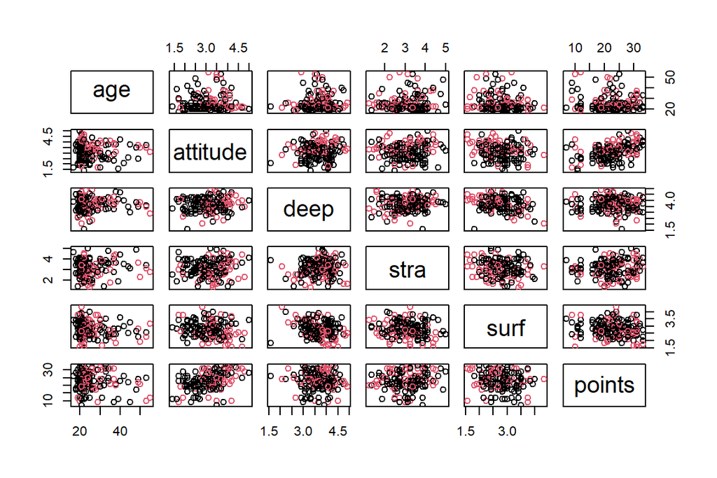

```r
pairs(students2014[-1], col = students2014$gender)# Females and males in different colours, F=black, M=red
```

```r
summary(students2014)
```

```
##  gender       age           attitude          deep            stra
##  F:110   Min.   :17.00   Min.   :1.400   Min.   :1.583   Min.   :1.250
##  M: 56   1st Qu.:21.00   1st Qu.:2.600   1st Qu.:3.333   1st Qu.:2.625
##          Median :22.00   Median :3.200   Median :3.667   Median :3.188
##          Mean   :25.51   Mean   :3.143   Mean   :3.680   Mean   :3.121
##          3rd Qu.:27.00   3rd Qu.:3.700   3rd Qu.:4.083   3rd Qu.:3.625
##          Max.   :55.00   Max.   :5.000   Max.   :4.917   Max.   :5.000
##       surf           points
##  Min.   :1.583   Min.   : 7.00
##  1st Qu.:2.417   1st Qu.:19.00
##  Median :2.833   Median :23.00
##  Mean   :2.787   Mean   :22.72
##  3rd Qu.:3.167   3rd Qu.:27.75
##  Max.   :4.333   Max.   :33.00
```

#### Linear models

I chose age, attitude and deep as explanatory variables and fitted the linear model where points is the target variable.

```r
model1 <- lm(points ~ age + attitude + deep, data = students2014)
summary(model1)
```

```
##
## Call:
## lm(formula = points ~ age + attitude + deep, data = students2014)
##
## Residuals:
##     Min      1Q  Median      3Q     Max
## -17.206  -3.430   0.204   3.979  10.950
##
## Coefficients:
##             Estimate Std. Error t value Pr(>|t|)
## (Intercept) 15.60773    3.38966   4.605 8.32e-06 ***
## age         -0.07716    0.05322  -1.450    0.149
## attitude     3.59413    0.56959   6.310 2.56e-09 ***
## deep        -0.60275    0.75031  -0.803    0.423
## ---
## Signif. codes:  0 '***' 0.001 '**' 0.01 '*' 0.05 '.' 0.1 ' ' 1
##
## Residual standard error: 5.307 on 162 degrees of freedom
## Multiple R-squared:  0.2043, Adjusted R-squared:  0.1896
## F-statistic: 13.87 on 3 and 162 DF,  p-value: 4.305e-08
```

From the summary we can see the model1 parameters. Estimates tell the relationships between the explanatory variables and the target variable. By using the estimates we can also write down the linear equation: *points=15.60773-0.07716age+3.59413attitude-0.60275deep*.Then there are also standard errors in the summary, and t-values from the statistical test that was performed and p-values which tell if the explanatory variable is statistically significant variable. Usually we choose the level of significance, often it is 0,05. If we look at the variable age, we see that the p-value is 0,149 > 0,05, so age is not statistically significant variable. Variable deep is not either statistically significant variable because its p-value is even higher 0,423 > 0,05. But if we look at the variable attitude, p-value is very small 2.56e-09 < 0,05, which means that it is statistically significant.

Next I remove age and deep from the model, because they were not statistically significant.

```r
model2 <- lm(points ~  attitude, data = students2014)
summary(model2)
```

```
##
## Call:
## lm(formula = points ~ attitude, data = students2014)
##
## Residuals:
##      Min       1Q   Median       3Q      Max
## -16.9763  -3.2119   0.4339   4.1534  10.6645
##
## Coefficients:
##             Estimate Std. Error t value Pr(>|t|)
## (Intercept)  11.6372     1.8303   6.358 1.95e-09 ***
## attitude      3.5255     0.5674   6.214 4.12e-09 ***
## ---
## Signif. codes:  0 '***' 0.001 '**' 0.01 '*' 0.05 '.' 0.1 ' ' 1
##
## Residual standard error: 5.32 on 164 degrees of freedom
## Multiple R-squared:  0.1906, Adjusted R-squared:  0.1856
## F-statistic: 38.61 on 1 and 164 DF,  p-value: 4.119e-09
```

From the summary we can see now the model2 parameters which have now changed a bit because of the removal of those other variables. If we look at the relationship between the variables points and attitude, the attitude is statistically significant variable, p-value is very small 4.12e-09 < 0,05. Model equation is: *points=11.6372+3.5255attitude*. This means that when attitude increases by one, exam points will increase 3.5255 points on average.

Multiple R-squared is: 0.1906.This means that the fitted model explains 19,06 % of the variation in exam points. In my opinion, R squared is quite low (R squared is always between 0 and 100 %), but on the other hand we have statistically significant variable, which is good.